# Exploratory Data Visualizations

## Visualizing the Crime Rate of Lahore in January 2015

##### Data Viz for Public Policy

##### October 15th, 2017

This is Assignment 3 of the class “Data Visualization in Public Policy” at UChicago (Fall, 2017) and involves producing meaningful data-driven graphs and narratives to accompany them. My data on crime incidences comes from the Punjab Police Department of Pakistan, and my timeframe of analysis is the month of January, 2015 for the city of Lahore.

#### Background

Lahore saw an increase in the number of crime incidences in 2016 by [34% from prior year](https://tribune.com.pk/story/1279895/crime-rises-34-last-year-lahore/). The most significant crime type is the street crime that involves cases of murder, burglary, theft, robbery and motorcycle snatching. Lahore is a politically and economically an important city and the rising crime rate leads to questions on how can law-enforcement agencies control the situation. Before we can get to the answer to that, it is vital to analyze different aspects of crime rate of Lahore such as where do most crimes occur, what type of crimes are higher in frequency, during what time periods do most crimes occur etc. The graphs attempt to shed light on these aspects.

```r
library("dplyr")
library("readr")
library("ggplot2")
library("lubridate")
library("viridis")
library("extrafont")
library("rmarkdown")
library("ggthemes")

FIR_2015_data <- read_csv("Data/Full_FIR_Details_2015(1).csv")

# rename a variable name
colnames(FIR_2015_data)[1] <- "Neighborhood"

# Common themes for axes
t_title <- theme(plot.title = element_text(family="Times New Roman", face="bold", size=20, hjust=0, margin = margin(0, 22, 0, 0)))
t_subtitle <- theme(plot.subtitle=element_text(size=11, family="Georgia", hjust=0, face="italic", color="#8E8883", margin = margin(10, 22, 22, 0)))
t_axis <- theme(axis.title = element_text(family = "Franklin Gothic Book",size=12, color="#635F5D", margin = margin(22, 0, 22, 0)))
axis_labels <- theme(axis.text=element_text(size=10))
t_caption <- theme(plot.caption=element_text(family = "Georgia", hjust = 0, size=8, face="italic", color="black"))
panel_background <- theme(panel.background = element_rect(fill = '#bdbdbd'))
color_plot <- theme(plot.background = element_rect(fill = '#E5E2E0'))
```

### Areas with highest number of crime incidences:

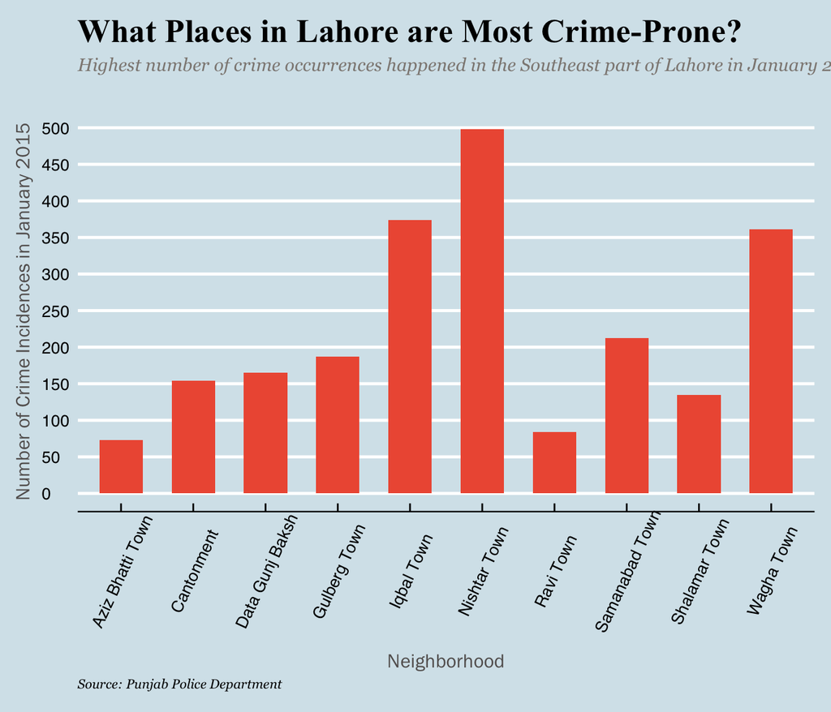

```r
summ_crimes_by_neighborhood <- group_by(FIR_2015_data, Neighborhood, `Crime Type`) %>%
  summarise(freq = n())

ggplot(data=summ_crimes_by_neighborhood, aes(x = Neighborhood, y= freq)) +
  geom_bar(stat="identity", width=0.6, fill="tomato2") +
  theme(aspect.ratio = .6) +
  scale_y_continuous(breaks = (seq(0, 500, by = 50))) +
  labs(title = "What Places in Lahore are Most Crime-Prone?", x = "Neighborhood", y = "Number of Crime Incidences in January 2015", subtitle="Highest number of crime occurrences happened in the Southeast part of Lahore in January 2015.", caption = "Source: Punjab Police Department") +
  theme_economist() +
  t_title + t_axis + t_subtitle + t_caption +
  theme(axis.text.x = element_text(angle=65, vjust=0.6))
```

The chart shows that most crimes in January 2015 occurred in Nishtar Town, Iqbal Town and Wagha Town whereas Ravi Town and Aziz Bhatti Town registered the lowest number of crime incidences in the same month.

It is not surprising most crime-prone areas such as Iqbal Town are the hub of commercial activities in the city and tend to be busy throughout the day. Road traffic accidents thus tend to be common. A bigger population of middle class families live in these areas, making them a soft target of criminals.

### Types of crime incidences in different areas:

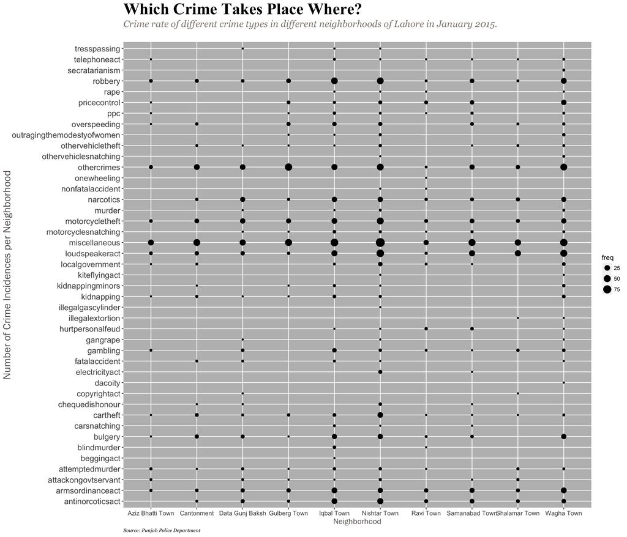

```r
ggplot(data=summ_crimes_by_neighborhood, aes(x = Neighborhood, y = `Crime Type`, size = freq)) +
  geom_point() +
  labs(title = "Which Crime Takes Place Where?", x = "Neighborhood", y = "Number of Crime Incidences per Neighborhood", subtitle="Crime rate of different crime types in different neighborhoods of Lahore in January 2015.", caption = "Source: Punjab Police Department") +
  t_title + t_axis + t_subtitle + t_caption + panel_background +
  theme(plot.title = element_text(family="Times New Roman", face="bold", size=26, hjust=0, margin = margin(0, 22, 0, 0))) +
  theme(plot.subtitle=element_text(size=15, family="Georgia", hjust=0, face="italic", color="#8E8883", margin = margin(10, 22, 22, 0))) + theme(axis.title.y = element_text(family = "Franklin Gothic Book",size=17, color="#635F5D", margin = margin(22, 0, 22, 0))) + theme(axis.title = element_text(family = "Franklin Gothic Book",size=13, color="#635F5D", margin = margin(22, 0, 22, 0))) + theme(axis.text.x=element_text(size=10)) + theme(axis.text.y=element_text(size=13))
```

### Average total number of crime incidences that occur in different time periods of the day

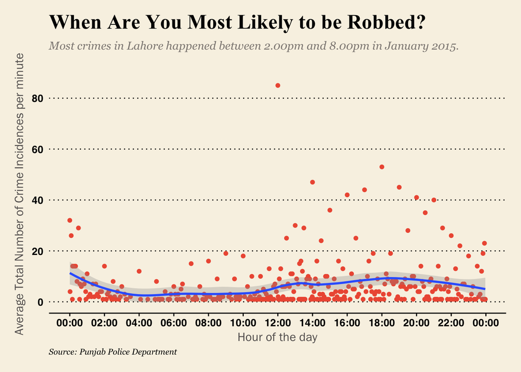

```r
by_time <- group_by(FIR_2015_data, Time)
summ_times <- summarise(by_time, freq = n())

summ_times$Time <- as.POSIXct(summ_times$Time, format="%H%M%S")

ggplot(summ_times, aes(Time, freq)) + geom_point(col="tomato2", size=1.5) +
  geom_smooth(method="loess", span=0.4, se=TRUE, alpha=0.3) +
  theme(aspect.ratio = .6) +
  scale_x_datetime(date_breaks=("2 hour"), date_labels=("%H:%M")) +
  labs(title = "When Are You Most Likely to be Robbed?", x = "Hour of the day", y = "Average Total Number of Crime Incidences per minute", subtitle="Most crimes in Lahore happened between 2.00pm and 8.00pm in January 2015.", caption = "Source: Punjab Police Department") +
  theme_wsj() + t_title + t_axis + t_subtitle + t_caption + axis_labels
```

### Distribution of crime incidences across all the week days:

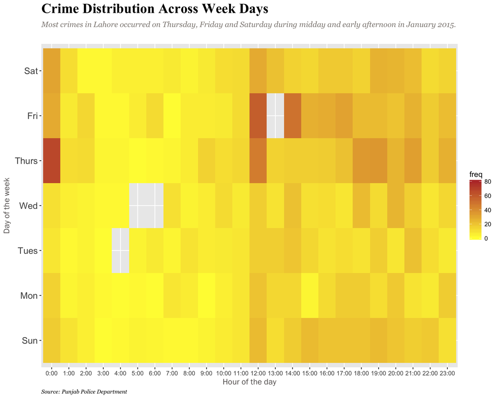

```r
# change Date type and create a new variable called "Month"
FIR_2015_data$Date <- dmy(FIR_2015_data$Date)
FIR_2015_data$week_day <- wday(FIR_2015_data$Date, label = TRUE)

# extra hours from the Time
FIR_2015_data$hour <- hour(FIR_2015_data$Time)

# summarise the count of crimes according to wday and time
by_wday_crime_count <- FIR_2015_data %>% group_by(week_day, hour) %>% summarise(freq = n())
k <- "00"
by_wday_crime_count$hour <- paste(by_wday_crime_count$hour, k, sep =":")

ggplot(by_wday_crime_count, aes(x = hour, y = week_day, fill = freq)) +
  geom_tile() +
  scale_x_discrete(limits = c("0:00", "1:00", "2:00", "3:00", "4:00", "5:00", "6:00", "7:00", "8:00", "9:00", "10:00", "11:00", "12:00", "13:00", "14:00", "15:00", "16:00", "17:00", "18:00", "19:00", "20:00", "21:00", "22:00", "23:00")) +
  scale_fill_gradient(low="#FFFB3F", high="#BA3833", limits=c(0, 80), na.value="transparent") +
  labs(title = "Crime Distribution Across Week Days", x = "Hour of the day", y = "Day of the week", subtitle="Most crimes in Lahore occurred on Thursday, Friday and Saturday during midday and early afternoon in January 2015.", caption = "Source: Punjab Police Department") +
  t_title + t_axis + t_subtitle + t_caption + theme(axis.text.y=element_text(size=13))
```

While we know that most crimes take place early and late afternoon, one can wonder if that pattern is common across all the days of the week. This chart demonstrates that Thursday, Friday and Saturday tend to be most crime-prone days of the week. During the week days, people barely go out to dine or take a walk. On the weekends, the traffic in Lahore increases, especially in the afternoon, because families come out to shop and dine, thereby resulting in higher chances of traffic accidents and incidences of robbery.

Moreover, it could also be seen that during such days, the incidences of crime tend to be higher in the afternoon than the incidences of crime in other week days.

### Distribution crime incidences across the week days by neighborhoods:

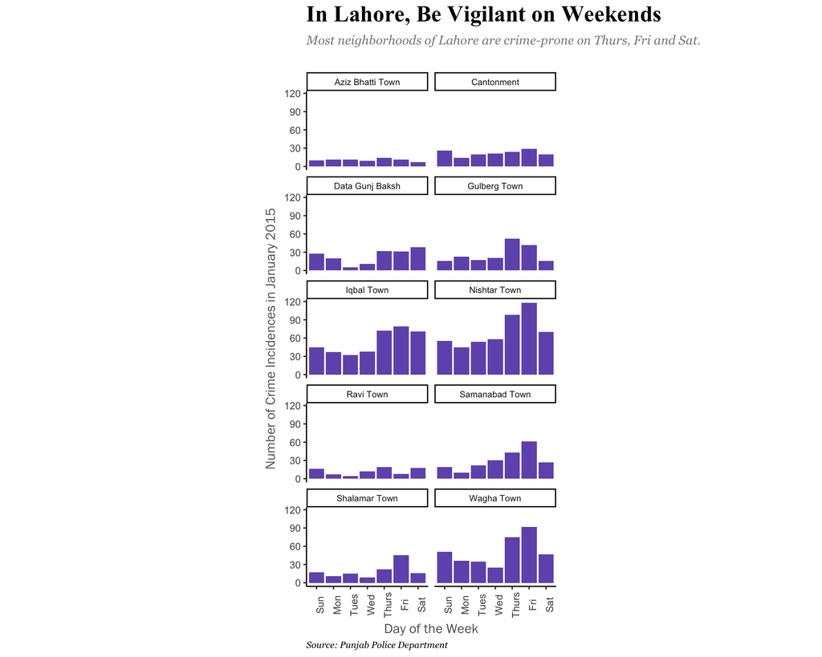

```r
theme_set(theme_classic())

by_wday_area_crime_count <- FIR_2015_data %>% group_by(week_day, Neighborhood) %>% summarise(freq = n())

ggplot(by_wday_area_crime_count, aes(x = week_day, y = freq)) +
  geom_bar(stat="identity", fill = "#7258BA") +
  facet_wrap(~Neighborhood, ncol = 2) +
  labs(title = "In Lahore, Be Vigilant on Weekends", x = "Day of the Week", y = "Number of Crime Incidences in January 2015", subtitle="Most neighborhoods of Lahore are crime-prone on Thurs, Fri and Sat.", caption = "Source: Punjab Police Department") +
  t_title + t_axis + t_subtitle + t_caption +
  theme(aspect.ratio = 0.65) +
  theme(axis.text.x = element_text(angle = 90),
        strip.text = element_text(face = "plain",
                                  size = rel(0.7)))
```